# Social Class and Confidence in Bankers

17 - April - 2015

### Introduction:

**Is a person’s social class an indicator of their confidence in banks and financial institutions?**

Is an American’s confidence in the American banking industry dependent on their “social class”? If whole sections of American society do not trust bankers are they making use of the services that banks provide? The answer to these questions could indicate that the American banking industry is failing to provide needed services to whole sections of society. While at the same time reductions in employer sponsored retirement programs make it necessary for Americans to take charge of their own retirement planning. If there is an association between the two variables, class and confidence, more research needs to be done so the issues can be addressed.

### Data:

The General Social Survey (GSS), conducted by The NATIONAL OPINION RESEARCH CENTER (NORC), is a survey of the American public about their social attitudes. (Please see formal citation.)$^{1}$ It is an observational study conducted by interviewers utilizing a variation of the stratified sampling method. They collect the data by computer-assisted personal interview (CAPI), face-to-face interview, and telephone interview. Each person interviewed represents an individual case with their responses recorded for further study and analysis.

For the current analysis the cases of interest are the 1315 respondents who answered both of the following survey questions in the most recent year the data is available (2012). “If you were asked to use one of four names for your social class, which would you say you belong in: the lower class, the working class, the middle class, or the upper class?” Question one is a categorical variable with four levels each corresponding to a social class: “Lower”, “Working”, “Middle”, and “Upper”. The second question was “I am going to name some institutions in this country. As far as the people running these institutions are concerned, would you say you have a great deal of confidence, only some confidence, or hardly any confidence at all in them? a. Banks and financial institutions.” It is also a categorical variable and it has three levels: “Great”, “Some”, “Hardly any”, which indicate the respondent’s level of confidence in the financial industry. (Please see Appendix for a sample of the sample data.)$^{2}$

The reason for further studying these questions is to identify a possible trend in the attitudes of the American public at large. The findings of this analysis can be generalized to this population because the data for the 2012 GSS was collected using full probability sampling. Potential bias is introduced by non-response, 659 out of 1974 people (33%) did not answer at least one of the questions being studied. Also as noted in the General Social Survey, 1972-2012 [Cumulative File] Codebook, Appendix A:

*“In general, the GSS samples closely resemble distributions reported in the Census and other authoritative sources. Because of survey non-response, sampling variation, and various other factors the GSS sample does deviate from known population figures for some variables. The GSS does not calculate any post-stratification weights to adjust for such differences.”*

Even with these potential sources of basis the results of this analysis can, with caution, be used to gain insight to the social attitudes of the American public. However, this type of study cannot be used to establish causal links between these questions. There are numerous confounding variables that a survey of individuals does not record, which make causation impossible to determine.

### Exploratory data analysis:

The first step in the analysis was to clean the data for use, which involved taking a subset of the year 2012 data from the original dataset, and removing NAs and unused levels. I then took a closer look at the data to see if there was any indication of patterns. First I tabled the levels totals:

```
##               Class
## Confidence     Lower Class Working Class Middle Class Upper Class
##   A Great Deal          10            76           46          14
##   Only Some             64           277          308          24
##   Hardly Any            77           220          191           8
```

Looking at the values in the table there did appear to be a pattern. However, I felt a proportional table might give a truer sense of any possible association between the variables:

```
##                   Lower   Working     Middle     Upper
## A Great Deal 0.06622517 0.1326353 0.08440367 0.3043478
## Only Some    0.42384106 0.4834206 0.56513761 0.5217391
## Hardly Any   0.50993377 0.3839442 0.35045872 0.1739130
```

This is where you can see that 50% of the “Lower” class compared to 17% of the “Upper” class had “Hardly Any” confidence in the American banking industry. This to me suggested that there might be an association between social “class” and “confidence” in the financial sector, and further research was justified. A good visualization for this data is a mosaic plot:

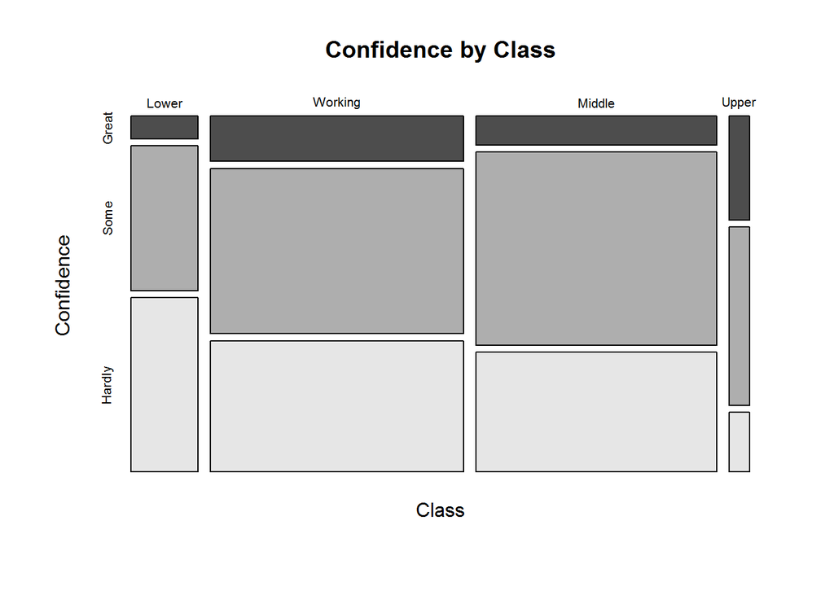

### Inference:

The goal of the analysis is to establish if there is an association between the two categorical variables. So the two hypotheses are:

$H_{O}$: Confidence in the financial industry and social class are independent. A respondent’s trust in bankers does not vary by social class.

$H_{A}$: Confidence in the financial industry and social class are dependent. A respondent’s trust in bankers does vary by social class.

The chi-square independence test is the appropriate method to test hypotheses when working with two categorical variables with multiple levels. And the two variables in this analysis are:

```
## [1] "$ Class     : Factor w/ 4 levels"
```

```
## [1] "$ Confidence: Factor w/ 3 levels"
```

In order to proceed the hypotheses needed to be evaluated and conditions needed to be checked. First a table with survey results (observed values) was created:

```
##        Lower Working Middle Upper  sum
## Great     10      76     46    14  146
## Some      64     277    308    24  673
## Hardly    77     220    191     8  496
## sum      151     573    545    46 1315
```

Then expected counts were calculated using data from the observed values table and the formula **(row total x column total) / grand total** , a table with the results was generated:

```
##           Lower   Working    Middle     Upper Totals
## Great  16.76502  63.61825  60.50951  5.107224    146
## Some   77.27985 293.25399 278.92395 23.542205    673
## Hardly 56.95513 216.12776 205.56654 17.350570    496
```

Comparing the observed values to the expected values shows large deviations that cannot be explained by chance alone. These deviations provide evidence for the alternative hypothesis.

Now conditions needed to be systematically checked. The GSS uses full probability sampling methodology, so the random sampling condition is met. There were 1315 individuals surveyed (ie sampling without replacement), and this represents less than ten percent (10%) of the population of the USA. Each person answered each question only once, so each case contributed to only one cell in the table. The sample size condition is met with each bin having at least five (5) expected cases. However, we must note that one of the bins had only 5.11 expected cases.

With conditions met, we can test the hypothesis about the association between class and confidence. With a chi-square independence test you use the following formula for each cell:

**(observed value – expected value)$^{2}$ / expected value**, these are the tabled results for this data:

```
##           Lower    Working   Middle        Upper
## Great  2.729820 2.40980705 3.479218 15.484234460
## Some   2.282023 0.90089914 3.030993  0.008902138
## Hardly 7.054618 0.06937688 1.032192  5.039209893
```

Since we are testing the independence of multi-level categorical variables we sum all the results from the table to get our test statistic (X$^{2}$) :

```
## [1] 43.52129
```

Next we calculate degrees of freedom using the formula **(number of rows – 1) X (number of columns – 1)** = degrees of freedom (df):

```
## [1] 6
```

With these two variables we can calculate the p-value:

```
## [1] 9.197043e-08
```

and we can also create a chi-square distribution plot:

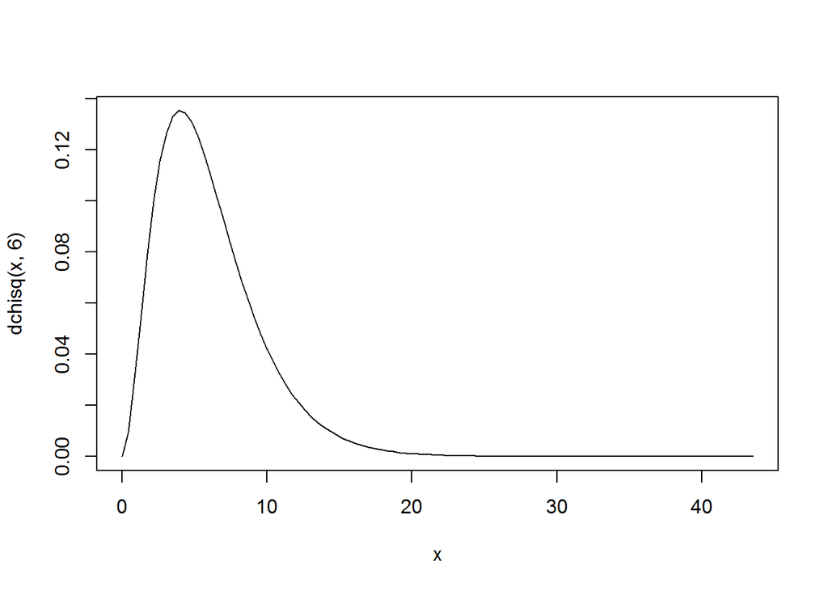

These results show quite large deviations from the null hypotheses, and for all practical purposes the p-value is equal to 0. Which means the probability of observing such an extreme test statistic (43.52), if the null hypothesis were true is equal to 0 (p-value = p(observed or more extreme test statistic | H$_{O}$ true). Therefore the null is rejected, and more research is suggested.

Since the two variables were multi-level categorical variables a chi-square independence test was used and other testing methods were not appropriate. I used the DASI Inference function to double check my methods and calculations, and the results were the same as mine:

```
## Response variable: categorical, Explanatory variable: categorical
## Chi-square test of independence
##
## Summary statistics:
##               x
## y              Lower Class Working Class Middle Class Upper Class  Sum
##   A Great Deal          10            76           46          14  146
##   Only Some             64           277          308          24  673
##   Hardly Any            77           220          191           8  496
##   Sum                  151           573          545          46 1315
```

```
## H_0: Response and explanatory variable are independent.
## H_A: Response and explanatory variable are dependent.
## Check conditions: expected counts
##               x
## y              Lower Class Working Class Middle Class Upper Class
##   A Great Deal       16.77         63.62        60.51        5.11
##   Only Some          77.28        293.25       278.92       23.54
##   Hardly Any         56.96        216.13       205.57       17.35
##
##  Pearson's Chi-squared test
##
## data:  y_table
## X-squared = 43.5213, df = 6, p-value = 9.197e-08
```

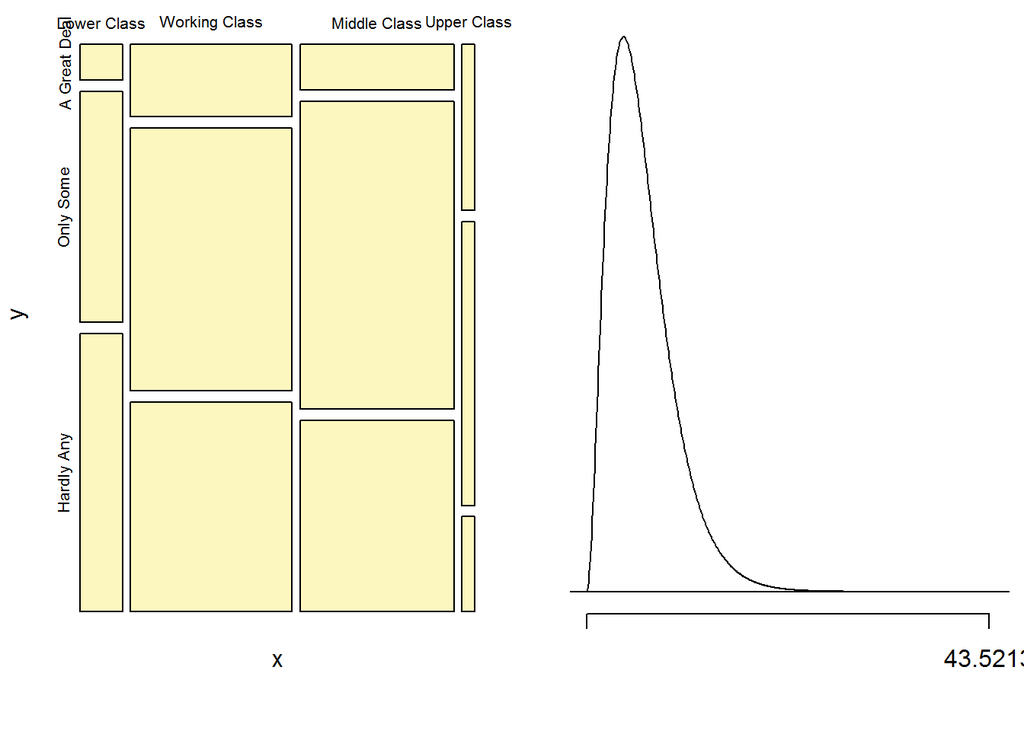

### Conclusion:

Now that the data from 2012 has been analyzed it would be interesting to analyze all the years that the data is available. Patterns in the data might emerge that would help us understand more about the associations between the two variables. For example it would be interesting to see if there was a dramatic change in confidence levels from 2006 to 2009. Especially to see if the members of the middle class, whose retirement plans took a loss during the 2007-2008 banking industry collapse, lost trust in the “people running these institutions”.

### $^{1}$References:

#### General Social Survey Cumulative File, 1972-2012 Coursera Extract

Modified for Data Analysis and Statistical Inference course (Duke University)

Modified download at: http://bit.ly/dasi_gss_data

Data Citation:

Smith, Tom W., Michael Hout, and Peter V. Marsden. General Social Survey, 1972-2012 [Cumulative File]. ICPSR34802-v1. Storrs, CT: Roper Center for Public Opinion Research, University of Connecticut /Ann Arbor, MI: Inter-university Consortium for Political and Social Research [distributors], 2013-09-11. doi:10.3886/ICPSR34802.v1

Persistent URL: http://doi.org/10.3886/ICPSR34802.v1

### $^{2}$Appendix:

```
##               Class   Confidence
## 55089  Middle Class   Hardly Any
## 55090  Middle Class    Only Some
## 55091   Upper Class A Great Deal
## 55092   Lower Class   Hardly Any
## 55094 Working Class    Only Some
## 55095 Working Class    Only Some
## 55097 Working Class    Only Some
## 55099 Working Class   Hardly Any
## 55100   Lower Class   Hardly Any
## 55102 Working Class    Only Some
## 55103  Middle Class    Only Some
## 55104 Working Class   Hardly Any
## 55105  Middle Class    Only Some
## 55106 Working Class   Hardly Any
```

[output cut: 16 more lines]